# TREC UserSim 2026 · NP Labs

## TREC UserSim 2026

A Simple Draft-and-Edit Baseline

Presented by

Nidhin Pattaniyil and Tanwir Zaman

Team NP Labs · November 18, 2026

## What the track asks

We play the **researcher** who needs a dataset. The organizers supply the **search assistant**.

[figure not shown]

Task 1

### Predict one reply

Read the conversation so far and write the researcher’s next message.

[figure not shown]

Task 2

### Run the conversation

Take turns with the assistant and decide when the researcher should stop.

[TREC UserSim participant guidelines](https://trec.usersim.ai/guidelines) · Notebook paper, §1

## The dataset search we will follow

Recorded Task 2 conversation

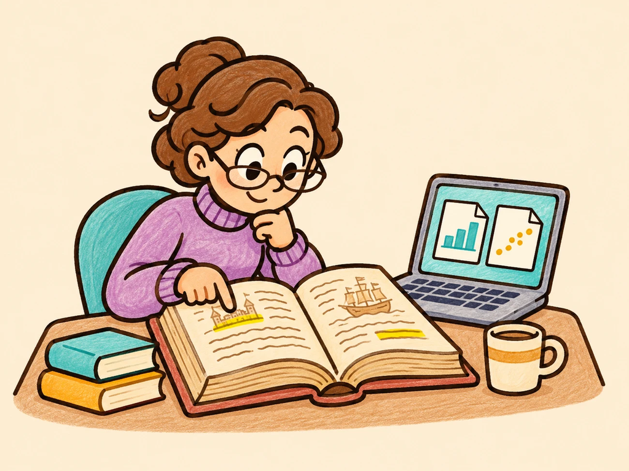

Find a dataset that labels people and places in historical texts.

The researcher prefers multilingual data.

UserSim notebook paper, §1

## What we gave GPT-6 Luna

Same dataset search · Before the first message

**Researcher profile**

Background, experience with AI, and traits.

**Search goal**

Find annotated datasets for named-entity recognition in the humanities, preferably multilingual.

**Domain knowledge**

How familiar the researcher is with the topic and which datasets they already know.

**Conversation history**

No messages yet. “Please start the conversation based on the goal and your persona.”

[figure not shown]

**Draft**Reply + stop decision

→

[figure not shown]

**Style edit**Revise wording

→

**Send**Edited text

**Task 2** · Keep the draft’s stop decision

UserSim notebook paper, §2 · Opening instruction quoted from the recorded prompt

## Our first message and the assistant’s reply

Same dataset search · First exchange

### Our simulator · submitted text

> “I’m looking for annotated NER datasets, preferably multilingual and covering humanities or historical texts. Which datasets are available, and what languages and entity types do they include?”

→

[figure not shown]

### Search assistant · summary

WikiANN and WikiNeural

The assistant offered these multilingual options. Its index had no annotated corpus specifically for humanities or historical texts.

Human-likeness by researcher turn

Recorded first exchange and preliminary organizer ratings. UserSim notebook paper, §1.

## Our style editor rarely changed the wording

[figure not shown]

### What we asked

Match the researcher’s tone with small edits.

> “If the draft fits, return it unchanged.”

→

### WikiANN follow-up · sent unchanged

> “Please provide the licensing, splits, and annotation provenance for WikiANN and WikiNeural, especially whether their annotations are human-verified.”

**4/4 human-likeness** · Preliminary organizer rating

Recorded Task 2 editor prompt and submitted reply. UserSim notebook paper, §2 and Figs. 1–2.

## The style pass kept the flagged formatting

### Turn 3 · Narrow the shortlist

**3/4** 607 characters

**Assistant summary** · Compared general NER benchmarks with humanities corpora.

**Read full replyShow key lines**

> “This is a useful overview, especially the distinction between broad modern benchmarks and humanities-focused corpora. Before I choose a combination, could you narrow it to a few strongest candidates and give the canonical project or dataset links? I’m particularly interested in which releases have human-annotated gold labels versus automatic or projected annotations, and in license/access details verified for the specific release—not just the underlying source text. Please flag any uncertainty, especially where names like HIPE or MasakhaNER refer to multiple versions with different contents or terms.”

> “… could you narrow it to a few strongest candidates and give the canonical project or dataset links?”

> “… license/access details verified for the specific release—not just the underlying source text.”

**Rater label** · Probably human

### Turn 4 · Check licenses

**0/4** 568 characters

**Assistant summary** · Linked MasakhaNER, HIPE, and LitBank. Exact release terms still needed checking.

**Read full replyShow key lines**

> “Thanks—this is a helpful shortlist, and I appreciate the caveats. I’m still hesitant to treat the license summaries as verified, since the answer points to project pages but doesn’t identify the exact release files or license documents. Could you do one focused check for **MasakhaNER 2.0, HIPE-2020, and LitBank**: give the precise release/repository location and state separately what terms apply to the annotations and to the underlying text? If a release has no clear license file or its terms are ambiguous, please say that explicitly rather than infer a license.”

> “Thanks—this is a helpful shortlist, and I appreciate the caveats.”

> “Could you do one focused check for **MasakhaNER 2.0, HIPE-2020, and LitBank**: … state separately what terms apply to the annotations and to the underlying text?”

**Rater flagged** · Dashes and literal `**`

Human-likeness by researcher turn

1. Turn 1 **1/4**
2. Turn 2 **2/4**
3. Turn 3 **3/4**
4. Turn 4 **0/4**
5. Turn 5 **1/4**

Preliminary organizer evaluation. Ellipses mark omissions. Assistant replies and rater comments summarized.

## Preliminary results for both tasks

| Measure | Task 162 reply predictions | Task 257 conversations |
| --- | --- | --- |
| Dialogue-act JSDLower means a closer match to the mix of human dialogue acts | **0.106** | **0.158** |
| Average human-likenessHuman ratings from 0 to 4 | **2.38/4**16 rated replies in 16 conversations | **2.31/4**67 rated replies in 14 conversations |
| Average reply lengthCharacters · NP Labs vs human reference | **563** vs 313 | **382** vs 199 |
| Average turns per conversationNP Labs vs human reference | One predicted reply per prompt | **4.7** vs 3.6 researcher turns8.2 vs 6.9 total turns |

**0**

Definitely a bot

**2**

Can't tell

**4**

Definitely human

Preliminary organizer evaluation, November 4. Task 2 counts include eight administrative closures. UserSim notebook paper, Fig. 3 and Table 1.

## Our replies were longer in both tasks

Characters per researcher reply

### Task 1 80% longer on average

Human avg.

**313**

NP Labs avg.

**563**

### Task 2 92% longer on average

Human avg.

**199**

NP Labs avg.

**382**

The two licensing replies · Human-likeness ratings

4/4 reply

**148**

0/4 reply

**568**

0300600

### Length barely tracked ratings

Rank correlation in the rated replies

Task 1 **+0.03** · Task 2 **−0.01**

### Ratings changed in both directions

Opening to final reply · 14 rated Task 2 conversations

**3**Higher

**7**Same

**4**Lower

Preliminary organizer evaluation. The length examples are individual replies from separate Task 2 searches. Rank correlations and opening-to-final counts use the rated subsets.

## What raters flagged in our replies

Selected examples from the preliminary Task 2 evaluation

### Visible formatting

**0/4**

> “Thanks—…” and “**MasakhaNER 2.0, HIPE-2020, and LitBank**”

The rater flagged the dashes and double asterisks.

### Tone shifted to expert

**1/4**

> “The joinability matters a lot for my use case.”

The rater noticed a shift from casual to expert language.

### Too much detail

**1/4**

> “… especially diabetes and cardiovascular history, BMI, smoking, activity, blood pressure, cholesterol, medications, and age.”

The rater found the request overly detailed.

### Closing recap

**1/4**

> “… compare it with IMS/PRONOSTIA while accounting for censoring and chronological splits.”

The rater found it unusual to end by recapping what the researcher planned to do.

Scores are human-likeness ratings. Excerpts are from our submitted replies. Rater comments are summarized.

## Conclusion

- **Simple prompting.** GPT-6 Luna drafted each reply, then ran a style pass.
- **Style refinement.** The editor left **95%** of Task 2 drafts unchanged, including the 4/4 and 0/4 replies.
- **Raters flagged** literal Markdown, dashes, an overly expert tone, excess detail, and closing recaps.
- **Preliminary scores.** Task 1 averaged **2.38/4** for human-likeness (JSD 0.106). Task 2 averaged **2.31/4** (JSD 0.158).

Task 2 draft/edit audit and preliminary organizer results. UserSim notebook paper, §§2–4.